# 01-💌NLP Sentiment Analysis Dating Apps Beoordelingen | 2017-2024 💌

# 📈Inleiding Eerste Notebook

Het hoofddoel van dit project is het analyseren van beoordelingen van dating-apps uit de Google Play Store van verschillende delen van de wereld. Door deze datasets samen te voegen, zal ik een NLP-sentimentanalyse uitvoeren om de diverse gedragingen en algemene gevoelens van gebruikers op verschillende datingplatforms te onderzoeken.

De analyse richt zich op het beantwoorden van deze twee onderzoeksvragen:

-Wat is het algemene tevredenheidspercentage van gebruikers over datingapps in het algemeen?

-Kunnen de sentiment scores gebruikt worden om de feedback van gebruikers te classificeren als positief, neutraal of negatief?

Daarnaast zullen we drie onderzoeksvragen om de analyse completer te maken en meer inzichten uit de dataset te halen:

- Zijn de beoordelingen in de loop van de tijd verslechterd of verbeterd?
- Wat zijn de gebruikelijke gedragingen en gevoelens die mensen hebben bij het gebruik van verschillende dating-apps (zoals Tinder, Bumble en Hinge)?
- Welke dating-app is het meest geschikt voor daten, relaties of biedt de beste functionaliteiten?

Daarna zullen we deze twee ML methodes aan de Analyse toepassen:

- Sentimentanalyse met TF-IDF vectorisatie en SVM/Logistic Regression.
- Tijdreeksen visualiseren met behulp van gemiddelde scores.

Aan het einde van deze notebook zal een samenvatting worden gepresenteerd met de belangrijkste inzichten uit de sentimentanalyse. De verschillende datasets die ik voor deze analyse heb gebruikt, zijn:

- Tinder Dating App - Google PLay Store Reviews (updated): https://www.kaggle.com/datasets/shivkumarganesh/tinder-google-play-store-review/data
- Bumble Dating App - Google Play Store Reviews (updated): https://www.kaggle.com/datasets/shivkumarganesh/bumble-dating-app-google-play-store-review
- Hinge Dating App - Google Play Store Reviews (updated): https://www.kaggle.com/datasets/shivkumarganesh/hinge-google-play-store-review

Er zijn twee delen (notebooks) voor deze data- analyse :

01- 💌 NLP Sentiment Analysis Dating Apps Beoordelingen | 2017-2023 💌: In deze notebook worden de volgende stappen uitgevoerd: datasets laden, Exploratory Data Analysis (EDA), data opschonen, en het samenvoegen van de drie datasets. Deze notebook richt zich voornamelijk op EDA en datavoorbereiding als voorbereiding op de volgende stap: een volledige sentimentanalyse van het definitieve dataset.

02- 💌 NLP Sentiment Analysis Dating Apps Beoordelingen | 2017-2023 💌: Na de EDA en het samenvoegen van alle datasets zal deze notebook zich richten op de volledige sentimentanalyse van het opgeschoonde dataset, inclusief aanvullende EDA.

# 📦Packages laden

In dit eerste deel van de notebook laden we de benodigde libraries voor het schoonmaken van data (cleaning), het uitvoeren van data-analyse (EDA), en het combineren (mergen) van datasets. In het tweede deel zullen we dieper ingaan op data-analyse en sentimentanalyse om voorspellingen te doen. Voor dit deel gebruiken we alleen de basisbibliotheken:

```python
# upload libraries
import pandas as pd
import numpy as np
import string
# Om grafieken te maken
import matplotlib.pyplot as plt
import seaborn as sns
```

# 👟Stappen voor het voorbereiden van data

In dit gedeelte laden we de datasets en beschrijven we de stappen die nodig zijn om tot een complete en opgeschoonde dataset te komen. Het proces verloopt als volgt:

Stap 1: Datasets laden

Stap 2: EDA & opschoning van elke dataset

- Vervolgens voeren we een EDA uit op elke dataset: Tinder Reviews, Bumble Reviews en Hinge Reviews.
- Daarna worden de datasets opgeschoond door onder andere null-waarden, duplicaten en onnodige kolommen te verwijderen.

Stap 3: Samenvoegen (mergen) van alle datasets

- Na de voorbereiding van de drie datasets (Tinder, Bumble en Hinge) combineren we ze tot één definitieve dataset.
- Tot slot wordt de gecombineerde dataset verder opgeschoond en geanalyseerd (laatste EDA), zodat deze gereed is voor verdere verwerking, zoals modellering of voorspellingen.

De laatste stap in dit proces zal in de tweede notebook worden uitgevoerd.

# 🪜Stap 1: Datasets laden

We gaan de drie datasets laden en daarna beginnen we met het analyseren (EDA) en het opschonen (cleaning) om inzichten te verkrijgen uit elke dataset.

```python
# Dataset laden van 'tinder_reviews'
tinder_reviews= pd.read_csv("C:\\Users\\kaile\\OneDrive\\Documents\\S4\\notebooks\\tinder app google play store\\tinder_google_play_reviews.csv")
tinder_reviews
```

|  | reviewId | userName | userImage | content | score | thumbsUpCount | reviewCreatedVersion | at | replyContent | repliedAt | appVersion |
| --- | --- | --- | --- | --- | --- | --- | --- | --- | --- | --- | --- |
| 0 | 2ee284b2-8239-4434-b2e0-e3ed60a67896 | A Google user | https://play-lh.googleusercontent.com/EGemoI2N... | Was banned without any reason, didn't break an... | 1 | 0 | 15.21.1 | 2024-11-21 23:59:49 | NaN | NaN | 15.21.1 |
| 1 | 6682e590-eb30-4ded-84af-8f8243b56442 | A Google user | https://play-lh.googleusercontent.com/EGemoI2N... | no funciona! Sencillamente no funciona | 1 | 0 | 15.21.1 | 2024-11-21 23:59:36 | NaN | NaN | 15.21.1 |
| 2 | e6f5db1f-6364-4ade-9e50-a089777af6e1 | A Google user | https://play-lh.googleusercontent.com/EGemoI2N... | thank you so much | 5 | 0 | 15.21.1 | 2024-11-21 23:44:24 | NaN | NaN | 15.21.1 |
| 3 | 2cd17dae-6488-4bbe-86db-a2e6e19da3af | A Google user | https://play-lh.googleusercontent.com/EGemoI2N... | All fake profiles, mostly people, try to scam ... | 5 | 0 | 15.21.1 | 2024-11-21 23:28:06 | NaN | NaN | 15.21.1 |
| 4 | 9925c76e-0722-4890-8fa6-d62557fc4cfe | A Google user | https://play-lh.googleusercontent.com/EGemoI2N... | Can't do anything before there is a match. Dis... | 1 | 0 | 15.21.1 | 2024-11-21 23:12:56 | NaN | NaN | 15.21.1 |
| ... | ... | ... | ... | ... | ... | ... | ... | ... | ... | ... | ... |
| 637211 | c9c6a2e3-4d65-4d3c-b434-d027dd7d81a9 | A Google user | https://play-lh.googleusercontent.com/EGemoI2N... | Best app ever finally on android | 5 | 2 | 1.0 | 2013-07-15 23:02:49 | NaN | NaN | 1.0 |
| 637212 | e418f4c2-78ca-4e93-93fa-d522d2ef2cb2 | A Google user | https://play-lh.googleusercontent.com/EGemoI2N... | Tinder is extremely buggy on the galaxy S4 act... | 1 | 0 | 1.0 | 2013-07-15 22:43:41 | Hi Steven, thanks for trying out Tinder! Pleas... | 2013-07-30 16:07:32 | 1.0 |
| 637213 | cfd8526b-e84b-4d4d-9989-3a5dc0a89b1a | A Google user | https://play-lh.googleusercontent.com/EGemoI2N... | Keeps crashing. | 1 | 0 | 1.0 | 2013-07-15 22:27:15 | Hi, thanks for trying out Tinder! Please updat... | 2013-07-30 16:07:41 | 1.0 |
| 637214 | 91829d43-289a-42af-b5ab-8f548339dd76 | A Google user | https://play-lh.googleusercontent.com/EGemoI2N... | Crashes. Doesn't load. Total failure. Take it ... | 1 | 0 | 1.0 | 2013-07-15 22:20:31 | Hi Wesley, thanks for trying out Tinder! Pleas... | 2013-07-30 16:07:52 | 1.0 |
| 637215 | f463cdfc-bd0a-42e0-a951-7de849cd95fd | A Google user | https://play-lh.googleusercontent.com/EGemoI2N... | Finally the real Tinder is on Android | 5 | 4 | 1.0 | 2013-07-15 21:07:56 | NaN | NaN | 1.0 |

637216 rows × 11 columns

```python
# Dataset laden van 'bumble_reviews'
bumble_reviews= pd.read_csv("C:\\Users\\kaile\\OneDrive\\Documents\\S4\\notebooks\\bumble app dating\\bumble_google_play_reviews.csv")
bumble_reviews
```

|  | reviewId | userName | userImage | content | score | thumbsUpCount | reviewCreatedVersion | at | replyContent | repliedAt | appVersion |
| --- | --- | --- | --- | --- | --- | --- | --- | --- | --- | --- | --- |
| 0 | 395888dc-c8b0-457d-a91e-8a90caf2f2d3 | A Google user | https://play-lh.googleusercontent.com/EGemoI2N... | Fake | 1 | 1 | 5.395.0 | 2024-11-23 23:41:33 | NaN | NaN | 5.395.0 |
| 1 | ed4fcee5-8614-4d1a-98bf-ff22f7b3261a | A Google user | https://play-lh.googleusercontent.com/EGemoI2N... | I h haven't received any responses yet I'm hav... | 3 | 0 | 5.395.0 | 2024-11-23 23:16:54 | We're sorry to hear about your negative experi... | 2024-11-24 08:45:30 | 5.395.0 |
| 2 | 4afcabd0-103d-47b9-a39a-b81554f556d2 | A Google user | https://play-lh.googleusercontent.com/EGemoI2N... | Scam. By the time you're (not) explaining how ... | 1 | 0 | 5.395.0 | 2024-11-23 23:01:39 | We’re sorry your experience wasn’t positive, D... | 2024-11-23 22:56:00 | 5.395.0 |
| 3 | 541fde8b-8a55-46a9-b2b3-2445f06d3ba1 | A Google user | https://play-lh.googleusercontent.com/EGemoI2N... | On registration when I reach at stage of A qui... | 3 | 0 | 5.395.0 | 2024-11-23 22:09:04 | This shouldn't be happening and sounds like so... | 2024-11-24 08:45:00 | 5.395.0 |
| 4 | fddb7ba9-54ca-410b-9707-247347d9ff98 | A Google user | https://play-lh.googleusercontent.com/EGemoI2N... | Pay money to find out who likes you.frig off t... | 1 | 2 | 5.395.0 | 2024-11-23 21:47:56 | You don't need to spend any money to match wit... | 2024-11-24 08:44:29 | 5.395.0 |
| ... | ... | ... | ... | ... | ... | ... | ... | ... | ... | ... | ... |
| 160107 | 61bc7cdc-3085-4631-ac95-d8e42e2e0742 | A Google user | https://play-lh.googleusercontent.com/EGemoI2N... | Finally here! | 5 | 54 | 1.0.1 | 2015-12-01 02:17:24 | NaN | NaN | 1.0.1 |
| 160108 | 24d07489-88ad-496a-80ce-8f137c130323 | A Google user | https://play-lh.googleusercontent.com/EGemoI2N... | Finally! | 5 | 75 | 1.0.1 | 2015-12-01 02:09:05 | NaN | NaN | 1.0.1 |
| 160109 | 22a42d0d-7a12-400d-a2af-826f35d21581 | A Google user | https://play-lh.googleusercontent.com/EGemoI2N... | Finally, an app where women have to start the ... | 4 | 2 | 1.0.1 | 2015-12-01 00:18:53 | NaN | NaN | 1.0.1 |
| 160110 | 2480a41f-8863-4948-9f83-7d856bd9dc78 | A Google user | https://play-lh.googleusercontent.com/EGemoI2N... | At last we have Android version! | 5 | 60 | 1.0.0 | 2015-11-30 21:27:51 | NaN | NaN | 1.0.0 |
| 160111 | 6ebb270a-3b4b-4ff5-b98c-8899dcfd40ee | A Google user | https://play-lh.googleusercontent.com/EGemoI2N... | Nice and smooth. | 5 | 52 | NaN | 2015-11-29 23:15:25 | NaN | NaN | NaN |

160112 rows × 11 columns

```python
# Dataset van 'hinge_reviews'
hinge_reviews= pd.read_csv("C:\\Users\\kaile\\OneDrive\\Documents\\S4\\notebooks\\Hinge app reviews\\hinge_google_play_reviews.csv")
hinge_reviews
```

|  | reviewId | userName | userImage | content | score | thumbsUpCount | reviewCreatedVersion | at | replyContent | repliedAt | appVersion |
| --- | --- | --- | --- | --- | --- | --- | --- | --- | --- | --- | --- |
| 0 | 5cd19a5f-b6b8-4298-87ea-d97116d7499c | A Google user | https://play-lh.googleusercontent.com/EGemoI2N... | biased app | 1 | 4 | 9.62.0 | 2024-11-23 23:59:27 | NaN | NaN | 9.62.0 |
| 1 | 5579b219-854f-4b41-a360-16f7e7c48005 | A Google user | https://play-lh.googleusercontent.com/EGemoI2N... | Women be trippin 🤷 | 1 | 0 | 9.62.0 | 2024-11-23 23:36:35 | NaN | NaN | 9.62.0 |
| 2 | 391d871a-d162-421b-8188-65ba1dc3e16f | A Google user | https://play-lh.googleusercontent.com/EGemoI2N... | "the app designed to be deleted" because it's ... | 1 | 1 | 9.62.0 | 2024-11-23 22:41:52 | NaN | NaN | 9.62.0 |
| 3 | 789decfb-37ec-4f4b-bf93-ae372256568c | A Google user | https://play-lh.googleusercontent.com/EGemoI2N... | Happy to take your money and no matter how you... | 1 | 0 | 9.62.0 | 2024-11-23 22:21:52 | NaN | NaN | 9.62.0 |
| 4 | bf0bd8ce-a5b6-419a-b452-ea0bc71e7bc2 | A Google user | https://play-lh.googleusercontent.com/EGemoI2N... | Dumpster fire. basically useless without paying | 1 | 0 | 9.62.0 | 2024-11-23 22:05:57 | NaN | NaN | 9.62.0 |
| ... | ... | ... | ... | ... | ... | ... | ... | ... | ... | ... | ... |
| 73413 | ef1a89dd-cad6-4c85-9af0-333eb500702f | A Google user | https://play-lh.googleusercontent.com/EGemoI2N... | Useless - I'm in the UK and it tells me i'm ov... | 2 | 5 | 5.2.0 | 2017-07-11 20:14:10 | Sorry for the error there. The sudden heavy in... | 2017-07-11 21:31:17 | 5.2.0 |
| 73414 | edb91049-807f-41b3-a2f8-2b4e952089bd | A Google user | https://play-lh.googleusercontent.com/EGemoI2N... | I can't get past the initial set up. It won't... | 1 | 11 | 5.2.0 | 2017-07-11 20:06:57 | Sorry for the error there. The sudden heavy in... | 2017-07-11 21:31:11 | 5.2.0 |
| 73415 | 98fdcb74-6fc9-4602-97b4-2a581972c850 | A Google user | https://play-lh.googleusercontent.com/EGemoI2N... | This is incredible! A quality dating app for A... | 5 | 1 | 5.2.0 | 2017-07-11 20:02:32 | Right?? We've already seen a lot of new relati... | 2017-07-11 21:39:24 | 5.2.0 |
| 73416 | 05c33419-30bd-49a3-937a-3ad3bdbdf6fe | A Google user | https://play-lh.googleusercontent.com/EGemoI2N... | "Over Water" ... Can't choose location. | 2 | 8 | 5.2.0 | 2017-07-11 19:58:27 | Sorry for the error there. The sudden heavy in... | 2017-07-11 21:30:50 | 5.2.0 |
| 73417 | de67b68f-25db-4bb2-846a-bda37db1355d | A Google user | https://play-lh.googleusercontent.com/EGemoI2N... | My entire town counts as "over water" and I ca... | 2 | 15 | 5.2.0 | 2017-07-11 19:54:31 | Sorry for the error there. The sudden heavy in... | 2017-07-11 21:30:46 | 5.2.0 |

73418 rows × 11 columns

We gaan onderzoeken of deze drie datasets geschikt zijn voor verdere analyse. Daarnaast zullen we beoordelen of we de datasets kunnen samenvoegen om zowel de hoofdvraag als de aanvullende onderzoeksvragen te beantwoorden.

# 🪜Stap 2: EDA & Cleaning datasets

Allereerst combineren we de drie datasets die we gaan gebruiken om één samengevoegde dataset te creëren. Daarna starten we met het opschonen van de gegevens en voeren we een Exploratory Data Analysis (EDA) uit om de dataset geschikt te maken voor verdere analyse. We gaan de datasets (tinder_reviews, bumble_reviews, hinge_reviews) afzonderlijk opschonen en een Exploratory Data Analysis (EDA) uitvoeren voordat we de drie datasets samenvoegen. Daarna zullen we verder gaan met de data-analyse en het uitvoeren van sentimentanalyse en machine learning.

# Tinder Reviews EDA

```python
tinder_reviews.head()
```

|  | reviewId | userName | userImage | content | score | thumbsUpCount | reviewCreatedVersion | at | replyContent | repliedAt | appVersion |
| --- | --- | --- | --- | --- | --- | --- | --- | --- | --- | --- | --- |
| 0 | 2ee284b2-8239-4434-b2e0-e3ed60a67896 | A Google user | https://play-lh.googleusercontent.com/EGemoI2N... | Was banned without any reason, didn't break an... | 1 | 0 | 15.21.1 | 2024-11-21 23:59:49 | NaN | NaN | 15.21.1 |
| 1 | 6682e590-eb30-4ded-84af-8f8243b56442 | A Google user | https://play-lh.googleusercontent.com/EGemoI2N... | no funciona! Sencillamente no funciona | 1 | 0 | 15.21.1 | 2024-11-21 23:59:36 | NaN | NaN | 15.21.1 |
| 2 | e6f5db1f-6364-4ade-9e50-a089777af6e1 | A Google user | https://play-lh.googleusercontent.com/EGemoI2N... | thank you so much | 5 | 0 | 15.21.1 | 2024-11-21 23:44:24 | NaN | NaN | 15.21.1 |
| 3 | 2cd17dae-6488-4bbe-86db-a2e6e19da3af | A Google user | https://play-lh.googleusercontent.com/EGemoI2N... | All fake profiles, mostly people, try to scam ... | 5 | 0 | 15.21.1 | 2024-11-21 23:28:06 | NaN | NaN | 15.21.1 |
| 4 | 9925c76e-0722-4890-8fa6-d62557fc4cfe | A Google user | https://play-lh.googleusercontent.com/EGemoI2N... | Can't do anything before there is a match. Dis... | 1 | 0 | 15.21.1 | 2024-11-21 23:12:56 | NaN | NaN | 15.21.1 |

```python
tinder_reviews.info()
print("shape of the dataset -->>",np.shape(tinder_reviews))
```

```
<class 'pandas.core.frame.DataFrame'>
RangeIndex: 637216 entries, 0 to 637215
Data columns (total 11 columns):
 #   Column                Non-Null Count   Dtype
---  ------                --------------   -----
 0   reviewId              637216 non-null  object
 1   userName              637216 non-null  object
 2   userImage             637216 non-null  object
 3   content               635854 non-null  object
 4   score                 637216 non-null  int64
 5   thumbsUpCount         637216 non-null  int64
 6   reviewCreatedVersion  506553 non-null  object
 7   at                    637216 non-null  object
 8   replyContent          59430 non-null   object
 9   repliedAt             59430 non-null   object
 10  appVersion            506553 non-null  object
dtypes: int64(2), object(9)
memory usage: 53.5+ MB
shape of the dataset -->> (637216, 11)
```

Opmerkingen van de dataset informatie:

- De dtypes zijn de verkeerde dus we zullen op de correcte manier converteren
- Het opsplitsen van Date&Time maakt het makkelijker om te analyseren of beoordelingen verbeteren over tijd, met specifieke datums en tijdstippen apart.
- Onnodige kolommen verwijderen om de structuur van de dataset verebeteren voordat we de datasets aan elkaar brengen (mergen).

We gaan eerst de datatypes wijzigen naar de correcte types:

- Converteer reviewId naar string, omdat het is bestaat niet alleen uit cijfers maar ook letters. Het is puur als een identificator.
- Converteer score en thumbsUpCount naar gehele getallen (int).
- Converteer Date&Time (at) naar een datetime-object.
- Zorg ervoor dat content en userName strings zijn.

Daarna gaan we de Date & Time aan elkaar scheiding:

- We gaan de kolom Date&Time in twee aparte kolommen opsplitsen : één voor de datum en één voor de tijd. Daarna verwijderen we de oorspronkelijke kolom Date&Time, omdat deze niet meer nodig is.

Aan het eind we gaan de verschillende kolommen bekijken en daarna de onnodige kolommen verwijderen:

- Waar ik kan nu zien, is dat er verschillende kolommen dat kan verwijder zijn: userImage, replyContent, repliedAt...

```python
# Convert reviewId and UserName to string type
tinder_reviews['reviewId'] = tinder_reviews['reviewId'].astype('string')
tinder_reviews['userName'] = tinder_reviews['userName'].astype('string')
tinder_reviews['content'] = tinder_reviews['content'].astype('string')
```

```python
# Convert score and thumbsUpCount to int type
tinder_reviews['score'] = tinder_reviews['score'].astype(int)
tinder_reviews['thumbsUpCount'] = tinder_reviews['thumbsUpCount'].astype(int)
```

```python
tinder_reviews.info()
```

```
<class 'pandas.core.frame.DataFrame'>
RangeIndex: 637216 entries, 0 to 637215
Data columns (total 11 columns):
 #   Column                Non-Null Count   Dtype
---  ------                --------------   -----
 0   reviewId              637216 non-null  string
 1   userName              637216 non-null  string
 2   userImage             637216 non-null  object
 3   content               635854 non-null  string
 4   score                 637216 non-null  int32
 5   thumbsUpCount         637216 non-null  int32
 6   reviewCreatedVersion  506553 non-null  object
 7   at                    637216 non-null  object
 8   replyContent          59430 non-null   object
 9   repliedAt             59430 non-null   object
 10  appVersion            506553 non-null  object
dtypes: int32(2), object(6), string(3)
memory usage: 48.6+ MB
```

# Date & Time opsplitsen

In dit geval hebben we alleen de datum nodig om de verschillende reviews te classificeren en te zien of de reviews slechter of beter zijn geworden in de loop van de tijd. We gaan twee aparte kolommen creëren en daarna de kolom 'Time' verwijderen.

```python
tinder_reviews["Date"] = pd.to_datetime(tinder_reviews['at'], format='%Y-%m-%d %H:%M:%S').dt.date
```

```python
tinder_reviews["Time"] = pd.to_datetime(tinder_reviews['at'], format='%Y-%m-%d %H:%M:%S').dt.time
```

```python
tinder_reviews = tinder_reviews.drop("at",axis=1)
```

```python
tinder_reviews["Date"] = pd.to_datetime(tinder_reviews["Date"])
```

```python
tinder_reviews["Time"] = tinder_reviews["Time"].astype(str)
```

```python
tinder_reviews.info()
```

```
<class 'pandas.core.frame.DataFrame'>
RangeIndex: 637216 entries, 0 to 637215
Data columns (total 12 columns):
 #   Column                Non-Null Count   Dtype
---  ------                --------------   -----
 0   reviewId              637216 non-null  string
 1   userName              637216 non-null  string
 2   userImage             637216 non-null  object
 3   content               635854 non-null  string
 4   score                 637216 non-null  int32
 5   thumbsUpCount         637216 non-null  int32
 6   reviewCreatedVersion  506553 non-null  object
 7   replyContent          59430 non-null   object
 8   repliedAt             59430 non-null   object
 9   appVersion            506553 non-null  object
 10  Date                  637216 non-null  datetime64[ns]
 11  Time                  637216 non-null  object
dtypes: datetime64[ns](1), int32(2), object(6), string(3)
memory usage: 53.5+ MB
```

```python
#Reorder columns in a way that is understanding
new_column_order = ['reviewId', 'userName', 'userImage', 'content', 'score', 'thumbsUpCount', 'reviewCreatedVersion', 'Date', 'Time', 'replyContent', 'repliedAt', 'appVersion']
tinder_reviews = tinder_reviews[new_column_order]
```

```python
# Check if the order is corrected:
print(tinder_reviews.columns)
```

```
Index(['reviewId', 'userName', 'userImage', 'content', 'score',
       'thumbsUpCount', 'reviewCreatedVersion', 'Date', 'Time', 'replyContent',
       'repliedAt', 'appVersion'],
      dtype='object')
```

# Kolommen verwijderen

```python
# Onnodige kolommen verwijderen:
tinder_reviews.drop(['userImage','reviewCreatedVersion',  'Time', 'replyContent', 'repliedAt', 'appVersion'], axis=1, inplace=True)
```

```python
tinder_reviews.head()
```

|  | reviewId | userName | content | score | thumbsUpCount | Date |
| --- | --- | --- | --- | --- | --- | --- |
| 0 | 2ee284b2-8239-4434-b2e0-e3ed60a67896 | A Google user | Was banned without any reason, didn't break an... | 1 | 0 | 2024-11-21 |
| 1 | 6682e590-eb30-4ded-84af-8f8243b56442 | A Google user | no funciona! Sencillamente no funciona | 1 | 0 | 2024-11-21 |
| 2 | e6f5db1f-6364-4ade-9e50-a089777af6e1 | A Google user | thank you so much | 5 | 0 | 2024-11-21 |
| 3 | 2cd17dae-6488-4bbe-86db-a2e6e19da3af | A Google user | All fake profiles, mostly people, try to scam ... | 5 | 0 | 2024-11-21 |
| 4 | 9925c76e-0722-4890-8fa6-d62557fc4cfe | A Google user | Can't do anything before there is a match. Dis... | 1 | 0 | 2024-11-21 |

```python
# We gaan alleen de numerieke nummers dtypes van de describe tabel zien.
tinder_reviews.describe(include=[np.number])
```

|  | score | thumbsUpCount |
| --- | --- | --- |
| count | 637216.000000 | 637216.000000 |
| mean | 2.870292 | 1.878201 |
| std | 1.771274 | 30.684762 |
| min | 1.000000 | 0.000000 |
| 25% | 1.000000 | 0.000000 |
| 50% | 3.000000 | 0.000000 |
| 75% | 5.000000 | 0.000000 |
| max | 5.000000 | 5461.000000 |

```python
tinder_reviews.tail()
```

|  | reviewId | userName | content | score | thumbsUpCount | Date |
| --- | --- | --- | --- | --- | --- | --- |
| 637211 | c9c6a2e3-4d65-4d3c-b434-d027dd7d81a9 | A Google user | Best app ever finally on android | 5 | 2 | 2013-07-15 |
| 637212 | e418f4c2-78ca-4e93-93fa-d522d2ef2cb2 | A Google user | Tinder is extremely buggy on the galaxy S4 act... | 1 | 0 | 2013-07-15 |
| 637213 | cfd8526b-e84b-4d4d-9989-3a5dc0a89b1a | A Google user | Keeps crashing. | 1 | 0 | 2013-07-15 |
| 637214 | 91829d43-289a-42af-b5ab-8f548339dd76 | A Google user | Crashes. Doesn't load. Total failure. Take it ... | 1 | 0 | 2013-07-15 |
| 637215 | f463cdfc-bd0a-42e0-a951-7de849cd95fd | A Google user | Finally the real Tinder is on Android | 5 | 4 | 2013-07-15 |

# 🧼Cleaning Tinder Reviews

In deze stap zullen we de null warden vervangen en duplicates verwijderen.

```python
# Check non-null values for each column
print(tinder_reviews.isnull().sum())
```

```
reviewId            0
userName            0
content          1362
score               0
thumbsUpCount       0
Date                0
dtype: int64
```

```python
# Handle null values in 'content'
tinder_reviews = tinder_reviews.dropna(subset=['content'])
```

```python
# Verify if null values are replaced
print(tinder_reviews.isnull().sum())
```

```
reviewId         0
userName         0
content          0
score            0
thumbsUpCount    0
Date             0
dtype: int64
```

```python
# Controleer op duplicaten
print(tinder_reviews.duplicated().sum())# Controleer op duplicaten
```

```
0
```

# Visualisaties Tinder_Reviews

# 1. Verdeling van Scores

Deze grafiek toont de frequentie van beoordelingen in de tinder_reviews-dataset en laat de verdeling in verschillende scorecategorieën zien.

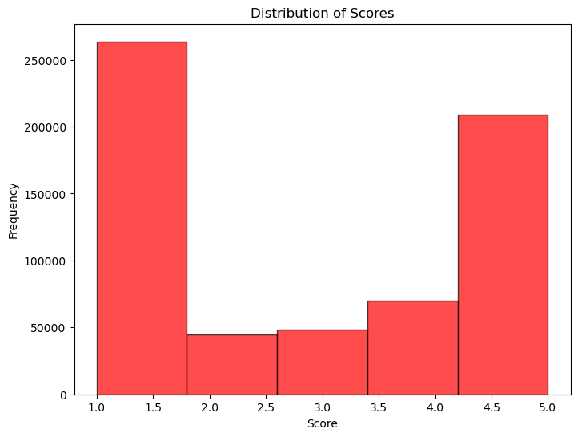

```python
# Histogram for the 'score' column om de distrubutie van scores
plt.figure(figsize=(8, 6))
plt.hist(tinder_reviews['score'], bins=5,color= 'red', edgecolor='black', alpha=0.7)
plt.title('Distribution of Scores')
plt.xlabel('Score')
plt.ylabel('Frequency')
plt.show()
```

De eerste grafiek laat zien dat de verdeling van scores sterk gepolariseerd is, met de meeste reviews geconcentreerd op scores van 1 en 5. Dit suggereert dat gebruikers over het algemeen zeer negatieve of zeer positieve ervaringen hebben, met weinig middelmatige beoordelingen.

# 2. Gemiddeld Aantal Duimen Omhoog per Score

Deze staafdiagram toont welke gemiddelde scores meer 'duimen omhoog' ontvangen.

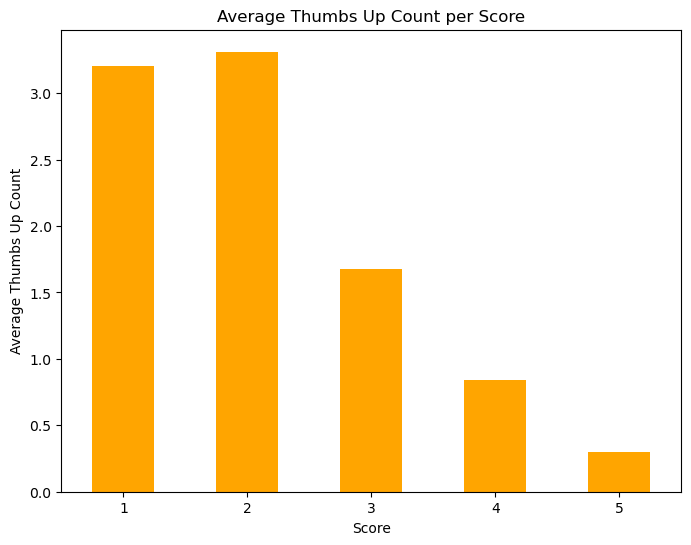

```python
# Bar Chart for Average Thumbs Up Count per Score
avg_thumbs_up = tinder_reviews.groupby('score')['thumbsUpCount'].mean()
plt.figure(figsize=(8, 6))
avg_thumbs_up.plot(kind='bar', color='orange')
plt.title('Average Thumbs Up Count per Score')
plt.xlabel('Score')
plt.ylabel('Average Thumbs Up Count')
plt.xticks(rotation=0)
plt.show()
```

De tweede grafiek toont aan dat reviews met lagere scores (1 en 2) gemiddeld meer duimpjes omhoog krijgen. Dit geeft aan dat negatieve reviews meer resoneren bij gebruikers, mogelijk omdat ze als nuttiger of herkenbaarder worden gezien.

# 3. Aantal Reviews in de Tijd

Een tijdreeksdiagram dat de verdeling van het aantal reviews over de tijd laat zien.

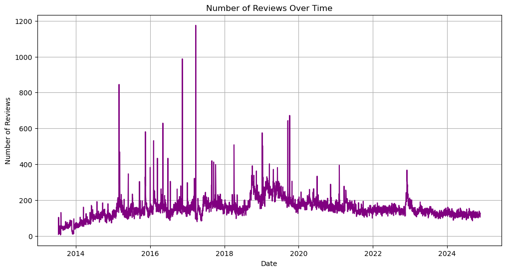

```python
# Reviews Over Time
tinder_reviews['Date'] = pd.to_datetime(tinder_reviews['Date'])
daily_reviews = tinder_reviews.groupby(tinder_reviews['Date'].dt.date).size()

plt.figure(figsize=(12, 6))
daily_reviews.plot(kind='line', color='purple')
plt.title('Number of Reviews Over Time')
plt.xlabel('Date')
plt.ylabel('Number of Reviews')
plt.grid(True)
plt.show()
```

De derde grafiek illustreert de trend van reviews over tijd, met een significante toename in activiteit tussen 2015 en 2017, gevolgd door een geleidelijke daling. Dit kan wijzen op een afname in populariteit van de app, veranderingen in gebruikersgedrag of een verschuiving in marketingfocus in latere jaren. We gaan dit grafiek verder onderzoeken met sentimentanalyse en de beoordelingen te koppelen aan specifieke trends in gebruikerservaringen of belangrijke gebeurtenissen in die periode.

# Conclusie

We kunnen concluderen dat deze dataset geschikt is voor verdere analyse en koppeling met andere datasets. Na de EDA en het opschonen van de data hebben we vastgesteld dat er geen ontbrekende waarden (NaN) aanwezig zijn, dat de datastructuur goed is, en dat alle benodigde informatie beschikbaar is om de beoordelingen verder te analyseren

Daarna gaan we met de EDA & Cleaning van de andere datase: Bumble Reviews

# Bumble Reviews EDA

```python
bumble_reviews.head()
```

|  | reviewId | userName | userImage | content | score | thumbsUpCount | reviewCreatedVersion | at | replyContent | repliedAt | appVersion |
| --- | --- | --- | --- | --- | --- | --- | --- | --- | --- | --- | --- |
| 0 | 395888dc-c8b0-457d-a91e-8a90caf2f2d3 | A Google user | https://play-lh.googleusercontent.com/EGemoI2N... | Fake | 1 | 1 | 5.395.0 | 2024-11-23 23:41:33 | NaN | NaN | 5.395.0 |
| 1 | ed4fcee5-8614-4d1a-98bf-ff22f7b3261a | A Google user | https://play-lh.googleusercontent.com/EGemoI2N... | I h haven't received any responses yet I'm hav... | 3 | 0 | 5.395.0 | 2024-11-23 23:16:54 | We're sorry to hear about your negative experi... | 2024-11-24 08:45:30 | 5.395.0 |
| 2 | 4afcabd0-103d-47b9-a39a-b81554f556d2 | A Google user | https://play-lh.googleusercontent.com/EGemoI2N... | Scam. By the time you're (not) explaining how ... | 1 | 0 | 5.395.0 | 2024-11-23 23:01:39 | We’re sorry your experience wasn’t positive, D... | 2024-11-23 22:56:00 | 5.395.0 |
| 3 | 541fde8b-8a55-46a9-b2b3-2445f06d3ba1 | A Google user | https://play-lh.googleusercontent.com/EGemoI2N... | On registration when I reach at stage of A qui... | 3 | 0 | 5.395.0 | 2024-11-23 22:09:04 | This shouldn't be happening and sounds like so... | 2024-11-24 08:45:00 | 5.395.0 |
| 4 | fddb7ba9-54ca-410b-9707-247347d9ff98 | A Google user | https://play-lh.googleusercontent.com/EGemoI2N... | Pay money to find out who likes you.frig off t... | 1 | 2 | 5.395.0 | 2024-11-23 21:47:56 | You don't need to spend any money to match wit... | 2024-11-24 08:44:29 | 5.395.0 |

```python
bumble_reviews.info()
print("shape of the dataset -->>",np.shape(bumble_reviews))
```

```
<class 'pandas.core.frame.DataFrame'>
RangeIndex: 160112 entries, 0 to 160111
Data columns (total 11 columns):
 #   Column                Non-Null Count   Dtype
---  ------                --------------   -----
 0   reviewId              160112 non-null  object
 1   userName              160112 non-null  object
 2   userImage             160112 non-null  object
 3   content               160096 non-null  object
 4   score                 160112 non-null  int64
 5   thumbsUpCount         160112 non-null  int64
 6   reviewCreatedVersion  131806 non-null  object
 7   at                    160112 non-null  object
 8   replyContent          115013 non-null  object
 9   repliedAt             115013 non-null  object
 10  appVersion            131806 non-null  object
dtypes: int64(2), object(9)
memory usage: 13.4+ MB
shape of the dataset -->> (160112, 11)
```

We gaan dezelfde stappen volgen als de vorige dataset: Tinder Reviews

Opmerkingen van de dataset informatie:

- De dtypes zijn de verkeerde dus we zullen op de correcte manier converteren
- Het opsplitsen van Date&Time maakt het makkelijker om te analyseren of beoordelingen verbeteren over tijd, met specifieke datums en tijdstippen apart.
- Onnodige kolommen verwijderen om de structuur van de dataset verebeteren voordat we de datasets aan elkaar brengen (mergen).

We gaan eerst de datatypes wijzigen naar de correcte types:

- Converteer reviewId naar string, omdat het is bestaat niet alleen uit cijfers maar ook letters. Het is puur als een identificator.
- Converteer score en thumbsUpCount naar gehele getallen (int).
- Converteer Date&Time (at) naar een datetime-object.
- Zorg ervoor dat content en userName strings zijn.

Daarna gaan we de Date & Time aan elkaar scheiding:

- We gaan de kolom Date&Time in twee aparte kolommen opsplitsen : één voor de datum en één voor de tijd. Daarna verwijderen we de oorspronkelijke kolom Date&Time, omdat deze niet meer nodig is.

Aan het eind we gaan de verschillende kolommen bekijken en daarna de onnodige kolommen verwijderen:

- Waar ik kan nu zien, is dat er verschillende kolommen dat kan verwijder zijn: userImage, replyContent, repliedAt...

```python
# Convert reviewId and UserName to string type
bumble_reviews['reviewId'] = bumble_reviews['reviewId'].astype('string')
bumble_reviews['userName'] = bumble_reviews['userName'].astype('string')
bumble_reviews['content'] = bumble_reviews['content'].astype('string')
```

```python
# Convert score and thumbsUpCount to int type
bumble_reviews['score'] = bumble_reviews['score'].astype(int)
bumble_reviews['thumbsUpCount'] = bumble_reviews['thumbsUpCount'].astype(int)
```

```python
bumble_reviews.info()
```

```
<class 'pandas.core.frame.DataFrame'>
RangeIndex: 160112 entries, 0 to 160111
Data columns (total 11 columns):
 #   Column                Non-Null Count   Dtype
---  ------                --------------   -----
 0   reviewId              160112 non-null  string
 1   userName              160112 non-null  string
 2   userImage             160112 non-null  object
 3   content               160096 non-null  string
 4   score                 160112 non-null  int32
 5   thumbsUpCount         160112 non-null  int32
 6   reviewCreatedVersion  131806 non-null  object
 7   at                    160112 non-null  object
 8   replyContent          115013 non-null  object
 9   repliedAt             115013 non-null  object
 10  appVersion            131806 non-null  object
dtypes: int32(2), object(6), string(3)
memory usage: 12.2+ MB
```

# Date& Time opsplitsen

```python
bumble_reviews["Date"] = pd.to_datetime(bumble_reviews['at'], format='%Y-%m-%d %H:%M:%S').dt.date
```

```python
bumble_reviews["Time"] = pd.to_datetime(bumble_reviews['at'], format='%Y-%m-%d %H:%M:%S').dt.time
```

```python
bumble_reviews = bumble_reviews.drop("at",axis=1)
```

```python
bumble_reviews["Date"] = pd.to_datetime(bumble_reviews["Date"])
```

```python
bumble_reviews["Time"] = bumble_reviews["Time"].astype(str)
```

```python
bumble_reviews.info()
```

```
<class 'pandas.core.frame.DataFrame'>
RangeIndex: 160112 entries, 0 to 160111
Data columns (total 12 columns):
 #   Column                Non-Null Count   Dtype
---  ------                --------------   -----
 0   reviewId              160112 non-null  string
 1   userName              160112 non-null  string
 2   userImage             160112 non-null  object
 3   content               160096 non-null  string
 4   score                 160112 non-null  int32
 5   thumbsUpCount         160112 non-null  int32
 6   reviewCreatedVersion  131806 non-null  object
 7   replyContent          115013 non-null  object
 8   repliedAt             115013 non-null  object
 9   appVersion            131806 non-null  object
 10  Date                  160112 non-null  datetime64[ns]
 11  Time                  160112 non-null  object
dtypes: datetime64[ns](1), int32(2), object(6), string(3)
memory usage: 13.4+ MB
```

```python
#Reorder columns in a way that is understanding
new_column_order = ['reviewId', 'userName', 'userImage', 'content', 'score', 'thumbsUpCount', 'reviewCreatedVersion', 'Date', 'Time', 'replyContent', 'repliedAt', 'appVersion']
bumble_reviews = bumble_reviews[new_column_order]
```

```python
# Check if the order is corrected:
print(bumble_reviews.columns)
```

```
Index(['reviewId', 'userName', 'userImage', 'content', 'score',
       'thumbsUpCount', 'reviewCreatedVersion', 'Date', 'Time', 'replyContent',
       'repliedAt', 'appVersion'],
      dtype='object')
```

# Kolommen vewijderen

```python
# Onnodige kolommen verwijderen:
bumble_reviews.drop(['userImage','reviewCreatedVersion',  'Time', 'replyContent', 'repliedAt', 'appVersion'], axis=1, inplace=True)
```

```python
bumble_reviews.head()
```

|  | reviewId | userName | content | score | thumbsUpCount | Date |
| --- | --- | --- | --- | --- | --- | --- |
| 0 | 395888dc-c8b0-457d-a91e-8a90caf2f2d3 | A Google user | Fake | 1 | 1 | 2024-11-23 |
| 1 | ed4fcee5-8614-4d1a-98bf-ff22f7b3261a | A Google user | I h haven't received any responses yet I'm hav... | 3 | 0 | 2024-11-23 |
| 2 | 4afcabd0-103d-47b9-a39a-b81554f556d2 | A Google user | Scam. By the time you're (not) explaining how ... | 1 | 0 | 2024-11-23 |
| 3 | 541fde8b-8a55-46a9-b2b3-2445f06d3ba1 | A Google user | On registration when I reach at stage of A qui... | 3 | 0 | 2024-11-23 |
| 4 | fddb7ba9-54ca-410b-9707-247347d9ff98 | A Google user | Pay money to find out who likes you.frig off t... | 1 | 2 | 2024-11-23 |

```python
# We gaan alleen de numerieke nummers dtypes van de describe tabel zien.
bumble_reviews.describe(include=[np.number])
```

|  | score | thumbsUpCount |
| --- | --- | --- |
| count | 160112.000000 | 160112.000000 |
| mean | 2.619454 | 3.127854 |
| std | 1.714390 | 30.123608 |
| min | 1.000000 | 0.000000 |
| 25% | 1.000000 | 0.000000 |
| 50% | 2.000000 | 0.000000 |
| 75% | 5.000000 | 1.000000 |
| max | 5.000000 | 3767.000000 |

```python
bumble_reviews.tail()
```

|  | reviewId | userName | content | score | thumbsUpCount | Date |
| --- | --- | --- | --- | --- | --- | --- |
| 160107 | 61bc7cdc-3085-4631-ac95-d8e42e2e0742 | A Google user | Finally here! | 5 | 54 | 2015-12-01 |
| 160108 | 24d07489-88ad-496a-80ce-8f137c130323 | A Google user | Finally! | 5 | 75 | 2015-12-01 |
| 160109 | 22a42d0d-7a12-400d-a2af-826f35d21581 | A Google user | Finally, an app where women have to start the ... | 4 | 2 | 2015-12-01 |
| 160110 | 2480a41f-8863-4948-9f83-7d856bd9dc78 | A Google user | At last we have Android version! | 5 | 60 | 2015-11-30 |
| 160111 | 6ebb270a-3b4b-4ff5-b98c-8899dcfd40ee | A Google user | Nice and smooth. | 5 | 52 | 2015-11-29 |

# 🧼Cleaning Bumble Reviews

In deze stap zullen we de null warden vervangen en duplicates verwijderen.

```python
# Check non-null values for each column
print(bumble_reviews.isnull().sum())
```

```
reviewId          0
userName          0
content          16
score             0
thumbsUpCount     0
Date              0
dtype: int64
```

```python
# Handle null values in 'content'
bumble_reviews = bumble_reviews.dropna(subset=['content'])
```

```python
# Verify if null values are replaced
print(bumble_reviews.isnull().sum())
```

```
reviewId         0
userName         0
content          0
score            0
thumbsUpCount    0
Date             0
dtype: int64
```

```python
# Controleer op duplicaten
print(bumble_reviews.duplicated().sum())# Controleer op duplicaten
```

```
0
```

# Visualisaties Bumble Reviews

# 1. Verdeling van scores

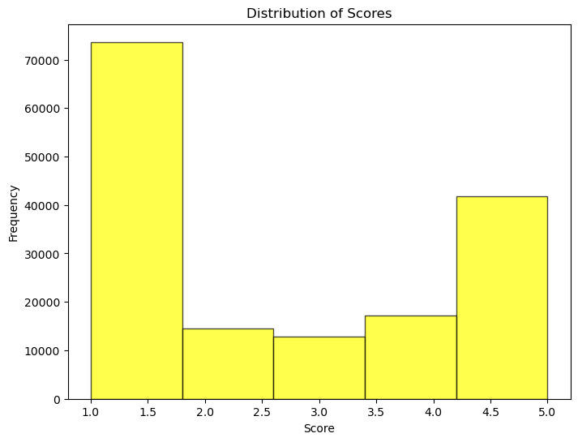

```python
# Histogram for the 'score' column om de distrubutie van scores
plt.figure(figsize=(8, 6))
plt.hist(bumble_reviews['score'], bins=5,color= 'yellow', edgecolor='black', alpha=0.7)
plt.title('Distribution of Scores')
plt.xlabel('Score')
plt.ylabel('Frequency')
plt.show()
```

De eerste visualisatie toont dat de scores sterk gepolariseerd zijn. De meeste gebruikers geven een score van 1 of 5, wat suggereert dat gebruikers ofwel erg ontevreden of juist erg tevreden zijn over hun ervaring. Dit wijst op een duidelijke verdeeldheid in de ervaringen van gebruikers, waarbij er weinig neutrale beoordelingen zijn.

# 2. Gemiddeld Aantal Duimen Omhoog per Score

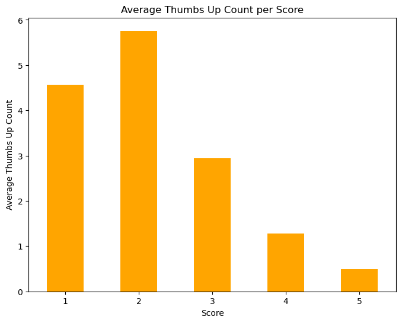

```python
# Bar Chart for Average Thumbs Up Count per Score
avg_thumbs_up = bumble_reviews.groupby('score')['thumbsUpCount'].mean()
plt.figure(figsize=(8, 6))
avg_thumbs_up.plot(kind='bar', color='orange')
plt.title('Average Thumbs Up Count per Score')
plt.xlabel('Score')
plt.ylabel('Average Thumbs Up Count')
plt.xticks(rotation=0)
plt.show()
```

De tweede grafiek laat zien dat beoordelingen met lagere scores, zoals 1 en 2, gemiddeld meer thumbs-ups ontvangen. Dit betekent dat negatieve beoordelingen meer interactie of betrokkenheid genereren van andere gebruikers, waarschijnlijk omdat deze als nuttiger of herkenbaarder worden beschouwd.

# 3. Aantal Reviews in de Tijd

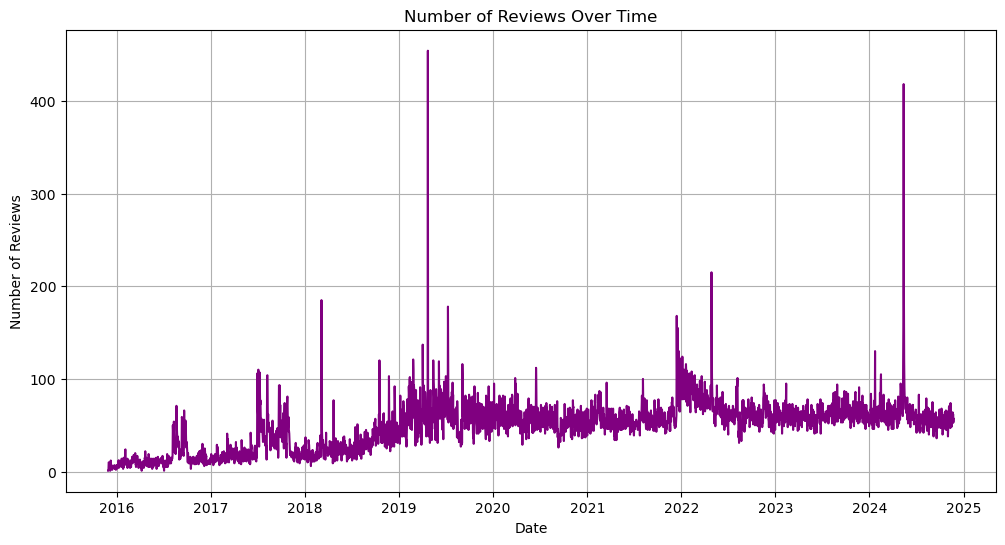

```python
# Reviews Over Time
bumble_reviews['Date'] = pd.to_datetime(bumble_reviews['Date'])
daily_reviews = bumble_reviews.groupby(bumble_reviews['Date'].dt.date).size()

plt.figure(figsize=(12, 6))
daily_reviews.plot(kind='line', color='purple')
plt.title('Number of Reviews Over Time')
plt.xlabel('Date')
plt.ylabel('Number of Reviews')
plt.grid(True)
plt.show()
```

# Conclusie

Net als bij de andere Tinder-reviewsdataset kunnen we concluderen dat ook deze dataset geschikt is voor verdere analyse. Na het uitvoeren van de EDA hebben we vastgesteld dat er geen ontbrekende waarden (NaN) zijn, de datastructuur goed is georganiseerd, en dat alle benodigde informatie aanwezig is om door te gaan met de sentimentanalyse en verder in te zoomen op de inhoud van de beoordelingen.

Daarna gaan we met de EDA & Cleaning van de andere datase: Hinge Reviews

# Hinge Reviews EDA

```python
hinge_reviews.head()
```

|  | reviewId | userName | userImage | content | score | thumbsUpCount | reviewCreatedVersion | at | replyContent | repliedAt | appVersion |
| --- | --- | --- | --- | --- | --- | --- | --- | --- | --- | --- | --- |
| 0 | 5cd19a5f-b6b8-4298-87ea-d97116d7499c | A Google user | https://play-lh.googleusercontent.com/EGemoI2N... | biased app | 1 | 4 | 9.62.0 | 2024-11-23 23:59:27 | NaN | NaN | 9.62.0 |
| 1 | 5579b219-854f-4b41-a360-16f7e7c48005 | A Google user | https://play-lh.googleusercontent.com/EGemoI2N... | Women be trippin 🤷 | 1 | 0 | 9.62.0 | 2024-11-23 23:36:35 | NaN | NaN | 9.62.0 |
| 2 | 391d871a-d162-421b-8188-65ba1dc3e16f | A Google user | https://play-lh.googleusercontent.com/EGemoI2N... | "the app designed to be deleted" because it's ... | 1 | 1 | 9.62.0 | 2024-11-23 22:41:52 | NaN | NaN | 9.62.0 |
| 3 | 789decfb-37ec-4f4b-bf93-ae372256568c | A Google user | https://play-lh.googleusercontent.com/EGemoI2N... | Happy to take your money and no matter how you... | 1 | 0 | 9.62.0 | 2024-11-23 22:21:52 | NaN | NaN | 9.62.0 |
| 4 | bf0bd8ce-a5b6-419a-b452-ea0bc71e7bc2 | A Google user | https://play-lh.googleusercontent.com/EGemoI2N... | Dumpster fire. basically useless without paying | 1 | 0 | 9.62.0 | 2024-11-23 22:05:57 | NaN | NaN | 9.62.0 |

```python
hinge_reviews.info()
print("shape of the dataset -->>",np.shape(hinge_reviews))
```

```
<class 'pandas.core.frame.DataFrame'>
RangeIndex: 73418 entries, 0 to 73417
Data columns (total 11 columns):
 #   Column                Non-Null Count  Dtype
---  ------                --------------  -----
 0   reviewId              73418 non-null  object
 1   userName              73418 non-null  object
 2   userImage             73418 non-null  object
 3   content               73411 non-null  object
 4   score                 73418 non-null  int64
 5   thumbsUpCount         73418 non-null  int64
 6   reviewCreatedVersion  61804 non-null  object
 7   at                    73418 non-null  object
 8   replyContent          1207 non-null   object
 9   repliedAt             1207 non-null   object
 10  appVersion            61804 non-null  object
dtypes: int64(2), object(9)
memory usage: 6.2+ MB
shape of the dataset -->> (73418, 11)
```

We gaan dezelfde stappen volgen als de vorige dataset: Bumble Reviews

Opmerkingen van de dataset informatie:

- De dtypes zijn de verkeerde dus we zullen op de correcte manier converteren
- Het opsplitsen van Date&Time maakt het makkelijker om te analyseren of beoordelingen verbeteren over tijd, met specifieke datums en tijdstippen apart.
- Onnodige kolommen verwijderen om de structuur van de dataset verebeteren voordat we de datasets aan elkaar brengen (mergen).

We gaan eerst de datatypes wijzigen naar de correcte types:

- Converteer reviewId naar string, omdat het is bestaat niet alleen uit cijfers maar ook letters. Het is puur als een identificator.
- Converteer score en thumbsUpCount naar gehele getallen (int).
- Converteer Date&Time (at) naar een datetime-object.
- Zorg ervoor dat content en userName strings zijn.

Daarna gaan we de Date & Time aan elkaar scheiding:

- We gaan de kolom Date&Time in twee aparte kolommen opsplitsen : één voor de datum en één voor de tijd. Daarna verwijderen we de oorspronkelijke kolom Date&Time, omdat deze niet meer nodig is.

Aan het eind we gaan de verschillende kolommen bekijken en daarna de onnodige kolommen verwijderen:

- Waar ik kan nu zien, is dat er verschillende kolommen dat kan verwijder zijn: userImage, replyContent, repliedAt...

```python
# Convert reviewId and UserName to string type
hinge_reviews['reviewId'] = hinge_reviews['reviewId'].astype('string')
hinge_reviews['userName'] = hinge_reviews['userName'].astype('string')
hinge_reviews['content'] = hinge_reviews['content'].astype('string')
```

```python
# Convert score and thumbsUpCount to int type
hinge_reviews['score'] = hinge_reviews['score'].astype(int)
hinge_reviews['thumbsUpCount'] = hinge_reviews['thumbsUpCount'].astype(int)
```

```python
hinge_reviews.info()
```

```
<class 'pandas.core.frame.DataFrame'>
RangeIndex: 73418 entries, 0 to 73417
Data columns (total 11 columns):
 #   Column                Non-Null Count  Dtype
---  ------                --------------  -----
 0   reviewId              73418 non-null  string
 1   userName              73418 non-null  string
 2   userImage             73418 non-null  object
 3   content               73411 non-null  string
 4   score                 73418 non-null  int32
 5   thumbsUpCount         73418 non-null  int32
 6   reviewCreatedVersion  61804 non-null  object
 7   at                    73418 non-null  object
 8   replyContent          1207 non-null   object
 9   repliedAt             1207 non-null   object
 10  appVersion            61804 non-null  object
dtypes: int32(2), object(6), string(3)
memory usage: 5.6+ MB
```

# Date&Time opsplitsen

```python
hinge_reviews["Date"] = pd.to_datetime(hinge_reviews['at'], format='%Y-%m-%d %H:%M:%S').dt.date
```

```python
hinge_reviews["Time"] = pd.to_datetime(hinge_reviews['at'], format='%Y-%m-%d %H:%M:%S').dt.time
```

```python
hinge_reviews = hinge_reviews.drop("at",axis=1)
```

```python
hinge_reviews["Date"] = pd.to_datetime(hinge_reviews["Date"])
```

```python
hinge_reviews["Time"] = hinge_reviews["Time"].astype(str)
```

```python
hinge_reviews.info()
```

```
<class 'pandas.core.frame.DataFrame'>
RangeIndex: 73418 entries, 0 to 73417
Data columns (total 12 columns):
 #   Column                Non-Null Count  Dtype
---  ------                --------------  -----
 0   reviewId              73418 non-null  string
 1   userName              73418 non-null  string
 2   userImage             73418 non-null  object
 3   content               73411 non-null  string
 4   score                 73418 non-null  int32
 5   thumbsUpCount         73418 non-null  int32
 6   reviewCreatedVersion  61804 non-null  object
 7   replyContent          1207 non-null   object
 8   repliedAt             1207 non-null   object
 9   appVersion            61804 non-null  object
 10  Date                  73418 non-null  datetime64[ns]
 11  Time                  73418 non-null  object
dtypes: datetime64[ns](1), int32(2), object(6), string(3)
memory usage: 6.2+ MB
```

```python
#Reorder columns in a way that is understanding
new_column_order = ['reviewId', 'userName', 'userImage', 'content', 'score', 'thumbsUpCount', 'reviewCreatedVersion', 'Date', 'Time', 'replyContent', 'repliedAt', 'appVersion']
hinge_reviews = hinge_reviews[new_column_order]
```

```python
# Check if the order is corrected:
print(hinge_reviews.columns)
```

```
Index(['reviewId', 'userName', 'userImage', 'content', 'score',
       'thumbsUpCount', 'reviewCreatedVersion', 'Date', 'Time', 'replyContent',
       'repliedAt', 'appVersion'],
      dtype='object')
```

# Kolommen vewijderen

```python
# Onnodige kolommen verwijderen:
hinge_reviews.drop(['userImage','reviewCreatedVersion',  'Time', 'replyContent', 'repliedAt', 'appVersion'], axis=1, inplace=True)
```

```python
hinge_reviews.head()
```

|  | reviewId | userName | content | score | thumbsUpCount | Date |
| --- | --- | --- | --- | --- | --- | --- |
| 0 | 5cd19a5f-b6b8-4298-87ea-d97116d7499c | A Google user | biased app | 1 | 4 | 2024-11-23 |
| 1 | 5579b219-854f-4b41-a360-16f7e7c48005 | A Google user | Women be trippin 🤷 | 1 | 0 | 2024-11-23 |
| 2 | 391d871a-d162-421b-8188-65ba1dc3e16f | A Google user | "the app designed to be deleted" because it's ... | 1 | 1 | 2024-11-23 |
| 3 | 789decfb-37ec-4f4b-bf93-ae372256568c | A Google user | Happy to take your money and no matter how you... | 1 | 0 | 2024-11-23 |
| 4 | bf0bd8ce-a5b6-419a-b452-ea0bc71e7bc2 | A Google user | Dumpster fire. basically useless without paying | 1 | 0 | 2024-11-23 |

```python
# We gaan alleen de numerieke nummers dtypes van de describe tabel zien.
hinge_reviews.describe(include=[np.number])
```

|  | score | thumbsUpCount |
| --- | --- | --- |
| count | 73418.000000 | 73418.000000 |
| mean | 2.813711 | 2.462067 |
| std | 1.706054 | 17.254089 |
| min | 1.000000 | 0.000000 |
| 25% | 1.000000 | 0.000000 |
| 50% | 3.000000 | 0.000000 |
| 75% | 5.000000 | 1.000000 |
| max | 5.000000 | 1159.000000 |

```python
hinge_reviews.tail()
```

|  | reviewId | userName | content | score | thumbsUpCount | Date |
| --- | --- | --- | --- | --- | --- | --- |
| 73413 | ef1a89dd-cad6-4c85-9af0-333eb500702f | A Google user | Useless - I'm in the UK and it tells me i'm ov... | 2 | 5 | 2017-07-11 |
| 73414 | edb91049-807f-41b3-a2f8-2b4e952089bd | A Google user | I can't get past the initial set up. It won't... | 1 | 11 | 2017-07-11 |
| 73415 | 98fdcb74-6fc9-4602-97b4-2a581972c850 | A Google user | This is incredible! A quality dating app for A... | 5 | 1 | 2017-07-11 |
| 73416 | 05c33419-30bd-49a3-937a-3ad3bdbdf6fe | A Google user | "Over Water" ... Can't choose location. | 2 | 8 | 2017-07-11 |
| 73417 | de67b68f-25db-4bb2-846a-bda37db1355d | A Google user | My entire town counts as "over water" and I ca... | 2 | 15 | 2017-07-11 |

# 🧼Cleaning Hinge Reviews

In deze stap zullen we de null warden vervangen en duplicates verwijderen.

```python
# Check non-null values for each column
print(hinge_reviews.isnull().sum())
```

```
reviewId         0
userName         0
content          7
score            0
thumbsUpCount    0
Date             0
dtype: int64
```

```python
# Handle null values in 'content'
hinge_reviews = hinge_reviews.dropna(subset=['content'])
```

```python
# Verify if null values are replaced
print(hinge_reviews.isnull().sum())
```

```
reviewId         0
userName         0
content          0
score            0
thumbsUpCount    0
Date             0
dtype: int64
```

```python
# Controleer op duplicaten
print(hinge_reviews.duplicated().sum())# Controleer op duplicaten
```

```
0
```

# Visualisaties Hinge Reviews

# 1. Verdeling van Scores

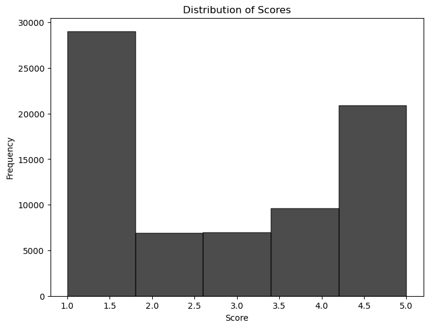

```python
# Histogram for the 'score' column om de distrubutie van scores
plt.figure(figsize=(8, 6))
plt.hist(hinge_reviews['score'], bins=5,color= 'black', edgecolor='black', alpha=0.7)
plt.title('Distribution of Scores')
plt.xlabel('Score')
plt.ylabel('Frequency')
plt.show()
```

De eerste visualisatie toont dat de scores sterk gepolariseerd zijn. De meeste gebruikers geven een score van 1 of 5, wat suggereert dat gebruikers ofwel erg ontevreden of juist erg tevreden zijn over hun ervaring. Dit wijst op een duidelijke verdeeldheid in de ervaringen van gebruikers, waarbij er weinig neutrale beoordelingen zijn.

# 2. Gemiddeld Aantal Duimen Omhoog per Score

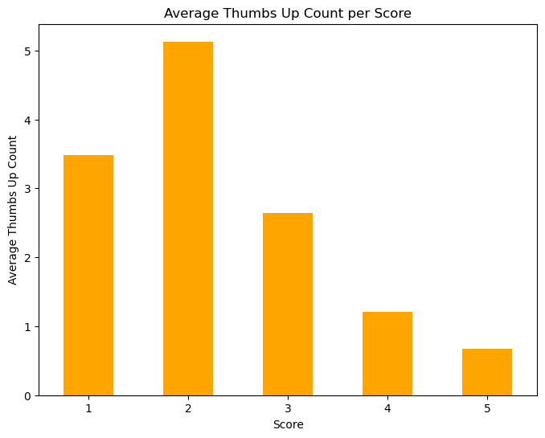

```python
# Bar Chart for Average Thumbs Up Count per Score
avg_thumbs_up = hinge_reviews.groupby('score')['thumbsUpCount'].mean()
plt.figure(figsize=(8, 6))
avg_thumbs_up.plot(kind='bar', color='orange')
plt.title('Average Thumbs Up Count per Score')
plt.xlabel('Score')
plt.ylabel('Average Thumbs Up Count')
plt.xticks(rotation=0)
plt.show()
```

De tweede grafiek laat zien dat beoordelingen met lagere scores, zoals 1 en 2, gemiddeld meer thumbs-ups ontvangen. Dit betekent dat negatieve beoordelingen meer interactie of betrokkenheid genereren van andere gebruikers, waarschijnlijk omdat deze als nuttiger of herkenbaarder worden beschouwd.

# 3. Aantal Reviews in de Tijd

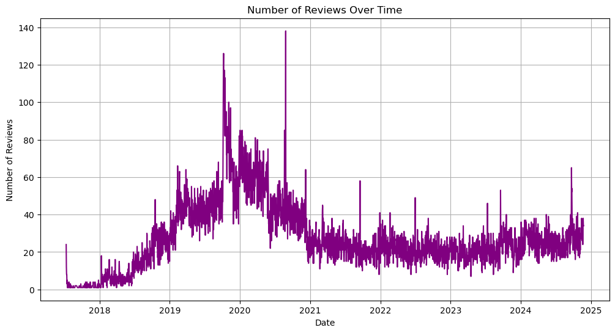

```python
# Reviews Over Time
hinge_reviews['Date'] = pd.to_datetime(hinge_reviews['Date'])
daily_reviews = hinge_reviews.groupby(hinge_reviews['Date'].dt.date).size()

plt.figure(figsize=(12, 6))
daily_reviews.plot(kind='line', color='purple')
plt.title('Number of Reviews Over Time')
plt.xlabel('Date')
plt.ylabel('Number of Reviews')
plt.grid(True)
plt.show()
```

De grafiek toont het aantal reviews over tijd, met een gestage groei tot eind 2019, gevolgd door significante pieken in 2020. Na deze pieken is er een duidelijke daling in het aantal reviews, dat vanaf 2021 op een lager niveau stabiliseert. De schommelingen in 2020 kunnen verband houden met gebeurtenissen zoals de COVID-19-pandemie, terwijl de daaropvolgende daling mogelijk wijst op verminderde gebruikersbetrokkenheid of marktverzadiging.

# Conclusie

Net als bij de andere twee ander datasets kunnen we concluderen dat ook deze dataset geschikt is voor verdere analyse. Na het uitvoeren van de EDA hebben we vastgesteld dat er geen ontbrekende waarden (NaN) zijn, de datastructuur goed is georganiseerd, en dat alle benodigde informatie aanwezig is om door te gaan met de sentimentanalyse en verder in te zoomen op de inhoud van de beoordelingen.

Na de EDA & cleaning van elke datasets, zullen we met de volgende stap: Merging Datasets

# 🪜Stap 3: Merging Datasets

In deze stap hebben we drie datasets gecombineerd door eerst een nieuwe kolom toe te voegen die de naam van de app aangeeft, zodat de herkomst van de gegevens duidelijk is. Vervolgens hebben we ervoor gezorgd dat de kolomnamen consistent zijn tussen de datasets. Daarna hebben we de datasets samengevoegd tot één uniforme dataset en deze weergegeven om te controleren of de samenvoeging correct is uitgevoerd.

```python
# Een nieuwe kolom toevoegen: 'App' in elke dataset
tinder_reviews['App'] = 'Tinder'
bumble_reviews['App'] = 'Bumble'
hinge_reviews['App'] = 'Hinge'
```

```python
# Kolomnamen op één lijn brengen voor consistentie vóór het samenvoegen
columns_to_keep = ['reviewId', 'userName', 'content', 'score', 'thumbsUpCount', 'Date', 'App']
tinder_reviews = tinder_reviews[columns_to_keep]
bumble_reviews = bumble_reviews[columns_to_keep]
himge_reviews = hinge_reviews[columns_to_keep]
```

```python
# Alle datasets samenvoegen tot één verenigde review-dataset
all_reviews_combined = pd.concat([tinder_reviews, bumble_reviews, hinge_reviews], ignore_index=True)
```

```python
# De DataFrame in een tabelweergave tonen
display(all_reviews_combined)
```

|  | reviewId | userName | content | score | thumbsUpCount | Date | App |
| --- | --- | --- | --- | --- | --- | --- | --- |
| 0 | 2ee284b2-8239-4434-b2e0-e3ed60a67896 | A Google user | Was banned without any reason, didn't break an... | 1 | 0 | 2024-11-21 | Tinder |
| 1 | 6682e590-eb30-4ded-84af-8f8243b56442 | A Google user | no funciona! Sencillamente no funciona | 1 | 0 | 2024-11-21 | Tinder |
| 2 | e6f5db1f-6364-4ade-9e50-a089777af6e1 | A Google user | thank you so much | 5 | 0 | 2024-11-21 | Tinder |
| 3 | 2cd17dae-6488-4bbe-86db-a2e6e19da3af | A Google user | All fake profiles, mostly people, try to scam ... | 5 | 0 | 2024-11-21 | Tinder |
| 4 | 9925c76e-0722-4890-8fa6-d62557fc4cfe | A Google user | Can't do anything before there is a match. Dis... | 1 | 0 | 2024-11-21 | Tinder |
| ... | ... | ... | ... | ... | ... | ... | ... |
| 869356 | ef1a89dd-cad6-4c85-9af0-333eb500702f | A Google user | Useless - I'm in the UK and it tells me i'm ov... | 2 | 5 | 2017-07-11 | Hinge |
| 869357 | edb91049-807f-41b3-a2f8-2b4e952089bd | A Google user | I can't get past the initial set up. It won't... | 1 | 11 | 2017-07-11 | Hinge |
| 869358 | 98fdcb74-6fc9-4602-97b4-2a581972c850 | A Google user | This is incredible! A quality dating app for A... | 5 | 1 | 2017-07-11 | Hinge |
| 869359 | 05c33419-30bd-49a3-937a-3ad3bdbdf6fe | A Google user | "Over Water" ... Can't choose location. | 2 | 8 | 2017-07-11 | Hinge |
| 869360 | de67b68f-25db-4bb2-846a-bda37db1355d | A Google user | My entire town counts as "over water" and I ca... | 2 | 15 | 2017-07-11 | Hinge |

869361 rows × 7 columns

```python
all_reviews_combined.drop_duplicates(inplace=True)
```

We zien dat de datasets succesvol zijn samengevoegd. De volgende stap is het uitvoeren van een EDA (Exploratory Data Analysis). Voordat we hiermee beginnen, slaan we de nieuwe dataset op, zodat we de vervolgstappen zorgvuldig kunnen uitvoeren. Daarna gaan we verder met de data-analyse en werken we de sentimentanalyse verder uit in de volende notebook: 02- 💌NLP Sentiment Analysis Dating Apps Beoordelingen | 2017-2023 💌 -> Volledige Sentiment Analyse van alle Dating App Reviews

```python
# Save the final merged dataset to a CSV file
all_reviews_combined.to_csv("all_reviews_combined.csv", index=False)
print("Merged dataset saved as 'all_reviews_combined.csv'")
```

```
Merged dataset saved as 'all_reviews_combined.csv'
```

# Eindconclusie

De eindconclusie over het gehele proces van data cleaning, voorbereiding en merging is dat de dataset zorgvuldig is geanalyseerd en opgeschoond om ervoor te zorgen dat deze klaar is voor verdere sentimentanalyse. Tijdens dit proces hebben we datasets gecombineerd en gecontroleerd op ontbrekende waarden (NaN), onnauwkeurigheden en inconsistenties. De structuur van de gegevens is geoptimaliseerd en er is gezorgd voor uniformiteit in de datavelden.

De laatste dataset blijkt de meest waardevolle te zijn, omdat deze geen ontbrekende waarden bevat, een goede datastructuur heeft en alle noodzakelijke informatie biedt voor diepgaande analyses. Bovendien weerspiegelt deze dataset de diversiteit en het sentiment van gebruikers beter dan eerdere datasets, waardoor deze niet alleen vollediger is, maar ook representatiever voor het onderwerp. Dit maakt de dataset de ideale keuze voor verdere sentimentanalyse en het beantwoorden van de onderzoeksvragen.

# 📃Bronnen

How to use Pandas for Data Cleaning and Preprocessing : https://www.freecodecamp.org/news/data-cleaning-and-preprocessing-with-pandasbdvhj/?utm_source=chatgpt.com

A Beginner's Guide to Data Cleaning in Phyton: https://www.datacamp.com/tutorial/guide-to-data-cleaning-in-python?utm_source=chatgpt.com

Step- by- Step EDA using Phyton: https://www.analyticsvidhya.com/blog/2022/07/step-by-step-exploratory-data-analysis-eda-using-python/?utm_source=chatgpt.com

The Importance of Data Cleaning: https://hex.tech/blog/data-cleaning-exploratory-data-analysis/?utm_source=chatgpt.com

Mastering Exploratory Data Analysis (EDA) For Dat Science Enthusiastics: https://www.analyticsvidhya.com/blog/2021/04/mastering-exploratory-data-analysiseda-for-data-science-enthusiasts/?utm_source=chatgpt.com

Exploratory Data Analysis: Techniques and Tools: https://datamites.com/blog/exploratory-data-analysis-techniques-and-tools/?utm_source=chatgpt.com